# 12_Factorial_Designs

Kristopher Kyle

3/29/2019

### Description of sample data

This data comprises a sample from the ICNALE corpus (Ishikawa, 2013). This sample includes vocabulary size test (VST) scores for participants from three representative countries (China, Japan, Thailand) at three CEFR proficiency levels (A2, B1, B2). Importantly, for this sample, proficiency level was determined by standardized test scores (e.g., TOEFL), and NOT VST score (which is the case for some participants in the larger dataset).

In this example, we will be examining whether there are differences between groups (Country and Proficiency) and VST scores. We would expect to see a difference in VST scores across different Proficiency groups, but we may not have any theoretically supported reason to expect differences between Country groups. However, our analysis will indicate whether any differences (and interactions) exist.

```r
mydata <- read.csv("data/factorial_sample.csv", header = TRUE)
summary(mydata)
```

```
##                     filename   Country        VST        Proficiency
##  W_CHN_PTJ0_001_B1_1.txt:  1   CHN: 59   Min.   :10.00   A2:122
##  W_CHN_PTJ0_010_B1_1.txt:  1   JPN:135   1st Qu.:22.00   B1:135
##  W_CHN_PTJ0_012_B1_1.txt:  1   THA:129   Median :28.00   B2: 66
##  W_CHN_PTJ0_013_B1_2.txt:  1             Mean   :28.38
##  W_CHN_PTJ0_014_B1_2.txt:  1             3rd Qu.:34.50
##  W_CHN_PTJ0_016_B1_2.txt:  1             Max.   :50.00
##  (Other)                :317
```

We can also easily summarize this data using the function “table”:

```r
table(mydata$Proficiency,mydata$Country)
```

```
##
##      CHN JPN THA
##   A2  11  64  47
##   B1  41  52  42
##   B2   7  19  40
```

### Visualizing the data

First, we will examine the data using boxplots:

```r
library("ggpubr")
```

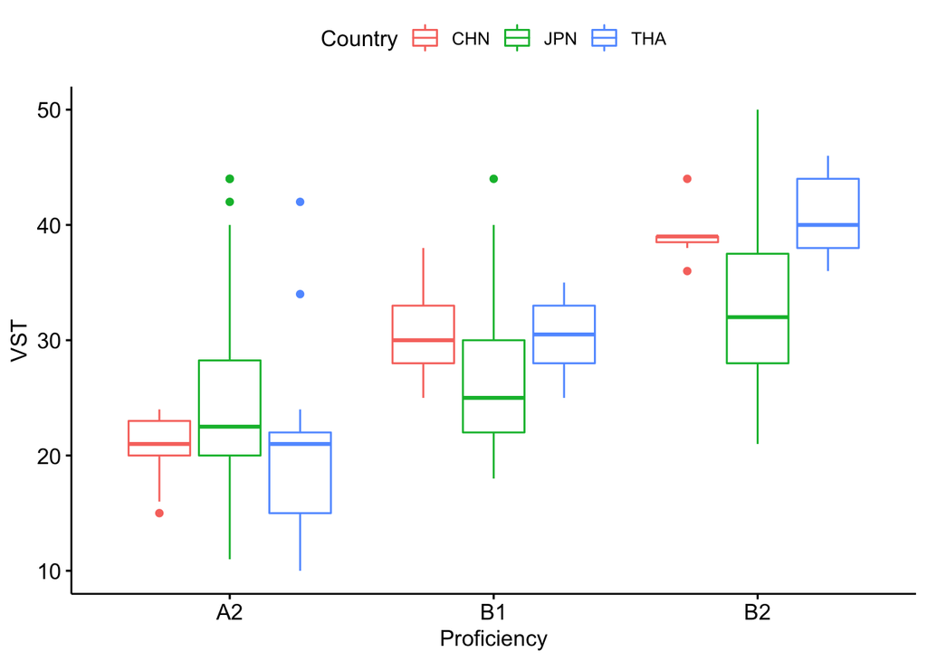

```r
ggboxplot(mydata, x = "Proficiency", y = "VST", color = "Country")
```

We can then more clearly identify trends (and interactions) using line plots. Below, we see that the VST scores for the China and Thailand groups appear to increase fairly evenly between proficiency groups. In contrast, the VST scores for the Japan group appear not to increase very much between A2 and B1 levels, but it does appear as though they increase between B1 and B2 levels.

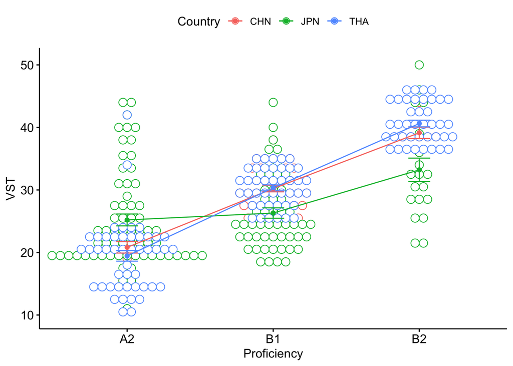

```r
ggline(mydata, x = "Proficiency", y = "VST", color = "Country",
       add = c("mean_se", "dotplot"))
```

### Running the analysis

```r
library(car)
fact_anova <- aov(VST ~ Proficiency * Country, data = mydata)
Anova(fact_anova, type = "III")
```

```
## Anova Table (Type III tests)
##
## Response: VST
##                     Sum Sq  Df F value    Pr(>F)
## (Intercept)         4767.4   1 155.698 < 2.2e-16 ***
## Proficiency         1501.2   2  24.514 1.281e-10 ***
## Country              935.9   2  15.283 4.637e-07 ***
## Proficiency:Country 2088.3   4  17.050 1.150e-12 ***
## Residuals           9614.4 314
## ---
## Signif. codes:  0 '***' 0.001 '**' 0.01 '*' 0.05 '.' 0.1 ' ' 1
```

As we can see, there are main effects for each of our fixed factors and for the interaction between them. Because there are significant differences between both of our fixed factors and between their interaction, we need to focus on the interactions!

### Running Post-Hocs

What we would do if there were no interactions:

```r
library(multcomp)
summary(glht(fact_anova, linfct = mcp(Country = "Tukey",Proficiency="Tukey")))
```

```
##
##   Simultaneous Tests for General Linear Hypotheses
##
## Multiple Comparisons of Means: Tukey Contrasts
##
##
## Fit: aov(formula = VST ~ Proficiency * Country, data = mydata)
##
## Linear Hypotheses:
##                           Estimate Std. Error t value Pr(>|t|)
## Country: JPN - CHN == 0      4.385      1.806   2.428   0.0688 .
## Country: THA - CHN == 0     -1.371      1.853  -0.740   0.8964
## Country: THA - JPN == 0     -5.756      1.063  -5.415   <0.001 ***
## Proficiency: B1 - A2 == 0    9.401      1.879   5.004   <0.001 ***
## Proficiency: B2 - A2 == 0   18.325      2.675   6.849   <0.001 ***
## Proficiency: B2 - B1 == 0    8.923      2.263   3.943   <0.001 ***
## ---
## Signif. codes:  0 '***' 0.001 '**' 0.01 '*' 0.05 '.' 0.1 ' ' 1
## (Adjusted p values reported -- single-step method)
```

However, we do have interactions, which means that our results are more complicated that what we see above (and in fact, what we see above is misleading), so we need to take a closer look at our data via a series of pairwise comparisons. Below, we will look at every single comparison in order to clarify our understanding of what is going on.

```r
library(emmeans)
marginal = emmeans(fact_anova, pairwise ~ Proficiency:Country, adjust = "Tukey")
summary(marginal)
```

```
## $emmeans
##  Proficiency Country emmean    SE  df lower.CL upper.CL
##  A2          CHN       20.8 1.668 314     17.5     24.1
##  B1          CHN       30.2 0.864 314     28.5     31.9
##  B2          CHN       39.1 2.091 314     35.0     43.3
##  A2          JPN       25.2 0.692 314     23.8     26.6
##  B1          JPN       26.3 0.767 314     24.8     27.8
##  B2          JPN       33.2 1.269 314     30.7     35.7
##  A2          THA       19.4 0.807 314     17.9     21.0
##  B1          THA       30.3 0.854 314     28.7     32.0
##  B2          THA       40.6 0.875 314     38.9     42.3
##
## Confidence level used: 0.95
##
## $contrasts
##  contrast        estimate   SE  df t.ratio p.value
##  A2,CHN - B1,CHN   -9.401 1.88 314  -5.004 <.0001
##  A2,CHN - B2,CHN  -18.325 2.68 314  -6.849 <.0001
##  A2,CHN - A2,JPN   -4.385 1.81 314  -2.428 0.2726
##  A2,CHN - B1,JPN   -5.490 1.84 314  -2.989 0.0730
##  A2,CHN - B2,JPN  -12.392 2.10 314  -5.911 <.0001
##  A2,CHN - A2,THA    1.371 1.85 314   0.740 0.9982
##  A2,CHN - B1,THA   -9.515 1.87 314  -5.077 <.0001
##  A2,CHN - B2,THA  -19.807 1.88 314 -10.514 <.0001
##  B1,CHN - B2,CHN   -8.923 2.26 314  -3.943 0.0032
##  B1,CHN - A2,JPN    5.016 1.11 314   4.532 0.0003
##  B1,CHN - B1,JPN    3.912 1.16 314   3.385 0.0225
##  B1,CHN - B2,JPN   -2.991 1.54 314  -1.948 0.5811
##  B1,CHN - A2,THA   10.773 1.18 314   9.110 <.0001
##  B1,CHN - B1,THA   -0.114 1.21 314  -0.094 1.0000
##  B1,CHN - B2,THA  -10.405 1.23 314  -8.461 <.0001
##  B2,CHN - A2,JPN   13.940 2.20 314   6.328 <.0001
##  B2,CHN - B1,JPN   12.835 2.23 314   5.761 <.0001
##  B2,CHN - B2,JPN    5.932 2.45 314   2.425 0.2742
##  B2,CHN - A2,THA   19.696 2.24 314   8.786 <.0001
##  B2,CHN - B1,THA    8.810 2.26 314   3.900 0.0037
##  B2,CHN - B2,THA   -1.482 2.27 314  -0.654 0.9992
##  A2,JPN - B1,JPN   -1.105 1.03 314  -1.069 0.9782
##  A2,JPN - B2,JPN   -8.007 1.45 314  -5.539 <.0001
##  A2,JPN - A2,THA    5.756 1.06 314   5.415 <.0001
##  A2,JPN - B1,THA   -5.130 1.10 314  -4.669 0.0002
##  A2,JPN - B2,THA  -15.422 1.12 314 -13.827 <.0001
##  B1,JPN - B2,JPN   -6.903 1.48 314  -4.653 0.0002
##  B1,JPN - A2,THA    6.861 1.11 314   6.160 <.0001
##  B1,JPN - B1,THA   -4.026 1.15 314  -3.507 0.0151
##  B1,JPN - B2,THA  -14.317 1.16 314 -12.303 <.0001
##  B2,JPN - A2,THA   13.764 1.50 314   9.149 <.0001
##  B2,JPN - B1,THA    2.877 1.53 314   1.881 0.6276
##  B2,JPN - B2,THA   -7.414 1.54 314  -4.809 0.0001
##  A2,THA - B1,THA  -10.887 1.17 314  -9.266 <.0001
##  A2,THA - B2,THA  -21.178 1.19 314 -17.791 <.0001
##  B1,THA - B2,THA  -10.292 1.22 314  -8.419 <.0001
##
## P value adjustment: tukey method for comparing a family of 9 estimates
```

It may be helpful at this point to look at the line plot we generated above, which clearly shows that the individuals from China and Thailand seem to be following the same trend (a steady increase of VST score at each proficiency level). Our pairwise comparisons confirm this. We see significant differences between each of the China proficiency levels and between each of the Thailand proficiency levels. Additionally, we do *not* see significant differences in VST scores between China and Thailand at any of the three proficiency levels (e.g., A2 China and A2 Thailand). These results suggest that it is reasonable to make generalizations regarding the Thailand and China groups in relation to proficiency and VST scores.

The participants from Japan, do not exhibit the same trend. The results indicate that there is no significance difference (p = 0.9782) in VST scores between A2 and B1 learners from the Japan group. There were, however, significant differences between A2 and B2 participants (p = < 0.0001) and between B1 and B2 participants (p = 0.0002) from the Japan group.

At the lowest proficiency level (A2), the Japan group has a higher mean VST score than the other two groups. The pairwise comparisons indicate that this is significantly higher than the Thailand group (p < 0.0001), but not significantly higher than the China group (p = 0.2726). At B1, we see that the Japan group has significantly lower VST scores that the China group (p = 0.0225) and the Thailand group (p = 0.0151). At B2, however, we only see significant differences between the Japan and Thailand group (p = 0.0001) - the differences between the Japan group and the China group are not significant (p = 0.2742).

### Getting effect sizes

We will have to do this the same way we did in the previous tutorial (i.e., by creating new dataframes and using the “cohen.d” function from the “psych” package). Below, we see that there is a large effect for the differences in VST scores between A2 and B1 (d = 2.3) and between B1 and B2 (d = 3.2) for the Thailand group.

```r
library(dplyr)
library(psych)
#create new df with only Beginner and Int
tha_a2b1 <- mydata %>%
  filter(Country == "THA") %>%
  filter(Proficiency == "A2" | Proficiency == "B1") %>%
  select(Proficiency, VST)

cohen.d(tha_a2b1,"Proficiency")
```

```
## Call: cohen.d(x = tha_a2b1, group = "Proficiency")
## Cohen d statistic of difference between two means
##     lower effect upper
## VST   1.7    2.3     3
##
## Multivariate (Mahalanobis) distance between groups
## [1] 2.3
## r equivalent of difference between two means
##  VST
## 0.76
```

```r
tha_b1b2 <-tha_a2b1 <- mydata %>%
  filter(Country == "THA") %>%
  filter(Proficiency == "B1" | Proficiency == "B2") %>%
  select(Proficiency, VST)
cohen.d(tha_b1b2,"Proficiency")
```

```
## Call: cohen.d(x = tha_b1b2, group = "Proficiency")
## Cohen d statistic of difference between two means
##     lower effect upper
## VST   2.4    3.2     4
##
## Multivariate (Mahalanobis) distance between groups
## [1] 3.2
## r equivalent of difference between two means
##  VST
## 0.85
```

### Checking assumptions

Next, we will check assumptions. As we will see, our data don’t meet the assumptions of homogeneity of variance or normality (sad face). In this case, we would need to analyze our data using non-parametric methods (which aren’t covered in this tutorial).

#### Homogeneity of variance

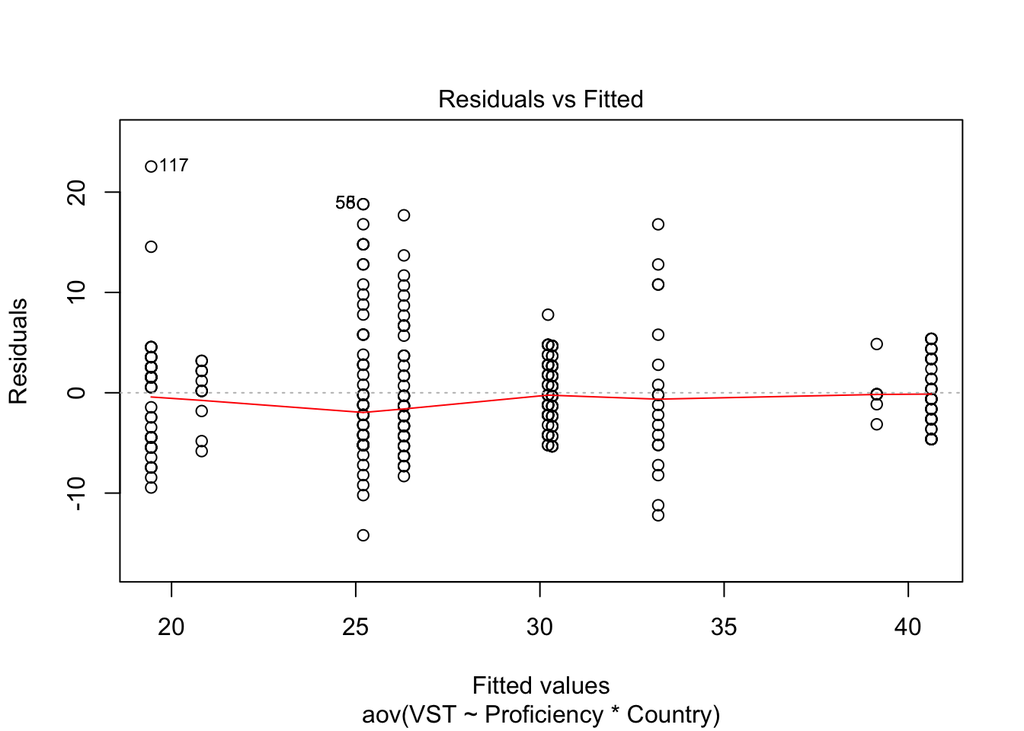

```r
plot(fact_anova, 1)
```

```r
library(car)
leveneTest(VST ~ Proficiency*Country, data = mydata)
```

```
## Levene's Test for Homogeneity of Variance (center = median)
##        Df F value   Pr(>F)
## group   8  4.6864 1.95e-05 ***
##       314
## ---
## Signif. codes:  0 '***' 0.001 '**' 0.01 '*' 0.05 '.' 0.1 ' ' 1
```

#### Normality

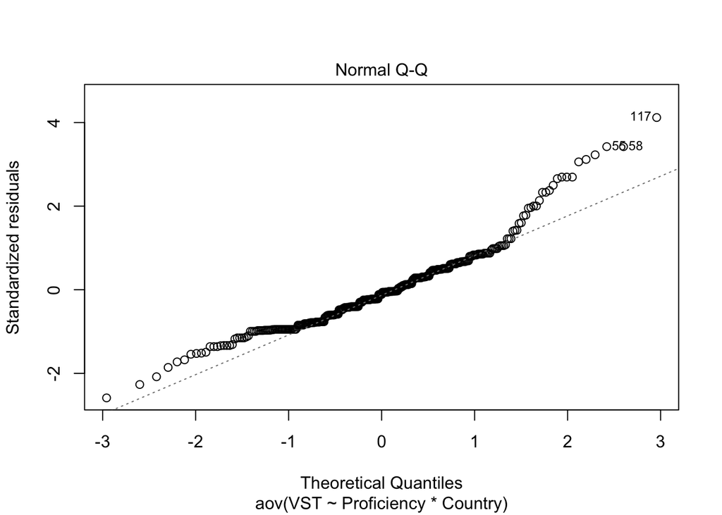

```r
plot(fact_anova,2)
```

```r
# Extract the residuals
aov_residuals <- residuals(object = fact_anova)
# Run Shapiro-Wilk test
shapiro.test(x = aov_residuals )
```

```
##
##  Shapiro-Wilk normality test
##
## data:  aov_residuals
## W = 0.93871, p-value = 2.696e-10
```